# GGMAP

Pedro Montenegro

9/11/2019

```r
library(ggmap)
library(tidyverse)
library(stringr)
library(RColorBrewer)
library(mapproj)
library(sp)
```

# Carga de datos

```r
load("../Otros/movimientos.Rdata")
load("../Otros/ubicaciones.RData")
map <- read_rds("../Otros/CRI_adm1.rds") %>% fortify() %>%
  filter(long < -82, long > -86, lat < 11.15, lat > 8)
#map <- getData(country = "CRI", level = 2)# obtener datos prov, canton
```

# Pregunta de investigación

Determinar uso de las tarjetas de crédito de los clientes $(Empresa)$ de forma geoespacial para conocer puntos de concentración y principales comercios.

MCC Transacciones de crédito

Los mcc de transferencias son reportes que emiten emisores de tarjetas como Mastercard, Visa, no incluye American Express.

# Explicación

Se presentan datos transaccionales de compras en tarjeta de crédito, además, el comercio asociado, por medio del API google vamos a aproximar la longitud y latitud de los comercios que se registran en los datos sobre las compras de tárjeta de crédito.

Para utilizar el API google vamos a registrarnos en el [link](https://cloud.google.com/maps-platform/), posteriormente, se registra en r con register_google(key = “Credenciales propias”), la página tiene 365 días sin costo y con $300 para uso.

# Resumen de las variables.

Periodo Agosto 2016 a enero 2017.

```r
glimpse(movimientos)
```

```
## Observations: 2,138,763
## Variables: 18
## $ mcc_cod   <chr> "0", "0", "0", "0", "0", "0", "0", "0", "0", "0", "0...
## $ mcc_cat   <chr> "DESCONOCIDO", "DESCONOCIDO", "DESCONOCIDO", "DESCON...
## $ tipo      <chr> "Compras", "Compras", "Compras", "Compras", "Compras...
## $ moneda    <chr> "Colones", "Colones", "Colones", "Colones", "Colones...
## $ ano       <int> 2016, 2016, 2016, 2016, 2016, 2016, 2016, 2016, 2016...
## $ mes       <int> 8, 8, 8, 8, 8, 8, 8, 8, 8, 8, 8, 8, 8, 8, 8, 8, 8, 8...
## $ dia       <int> 3, 1, 7, 2, 2, 1, 6, 4, 4, 7, 7, 2, 1, 5, 1, 6, 2, 3...
## $ semana    <int> 36, 32, 32, 36, 34, 33, 35, 35, 32, 35, 35, 36, 32, ...
## $ tipo_tarj <chr> "VISA Débito", "VISA Débito", "VISA Débito", "VISA D...
## $ categoria <chr> "Débito", "Débito", "Débito", "Débito", "Débito", "D...
## $ marca     <chr> "VISA", "VISA", "VISA", "VISA", "VISA", "VISA", "VIS...
## $ deb_cred  <chr> "Débito", "Débito", "Débito", "Débito", "Débito", "D...
## $ monto_col <dbl> 3035.76, 7148.25, 543.31, 1064.70, 5891.84, 8061.38,...
## $ fecha     <date> 2016-08-31, 2016-08-01, 2016-08-07, 2016-08-30, 201...
## $ comercio  <chr> "EXTERNO", "EXTERNO", "EXTERNO", "EXTERNO", "EXTERNO...
## $ pais      <chr> NA, NA, NA, NA, NA, NA, NA, NA, NA, NA, NA, NA, "CR"...
## $ monto     <dbl> 3035.76, 7148.25, 543.31, 1064.70, 5891.84, 8061.38,...
## $ token     <int> 32250, 30506, 14221, 29703, 60, 30451, 29851, 11261,...
```

Primero, nos va a interesar solo las transacciones clasificadas como compras y efectúadas en Costa Rica. Además, al comercio se le va a sumar el monto total de compras efectuadas por los movimientos.

```r
puntos <- movimientos %>% filter(pais %in% c("188", "CRC", "CR", "CRI"),
  tipo != "Adelantos") %>%
  group_by(comercio) %>% summarise(monto = sum(monto_col)) %>%
  arrange(desc(monto)) #%>% filter(!(comercio %in% ubicaciones$comercio))
```

Paramétros para buscar en el API google maps. Nombre del comercio y Pais, se construye una matriz con la misma longitud para extraer la longitud y latitud.

```r
val_buscar <- paste0(puntos$comercio, ", Costa Rica")
valores <- matrix(nrow = NROW(val_buscar), ncol = 2)
colnames(valores) <- c("longitud", "latitud")
```

# Función para extraer valores

```r
for (i in seq_along(val_buscar)) {
  query <- geocode(val_buscar[i], output = "all")
    if (query$status == "OK") {
      valores[i, 1] <- as.numeric(query$results[[1]]$geometry$location$lng)
      valores[i, 2] <- as.numeric(query$results[[1]]$geometry$location$lat)
      print(valores[i, ])
    }
    else if (query$status == "OVER_QUERY_LIMIT") {
      valores <- valores[1:(i - 1), ]
      break
    }
}
```

# Gráfico Costa Rica con las compras por comercio

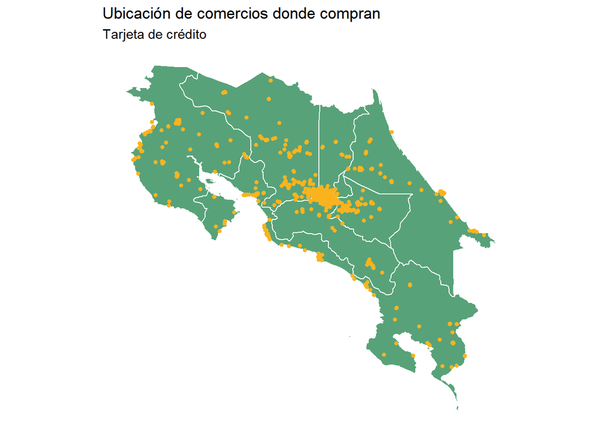

```r
ubicaciones %>%
  filter(lon < -82, lon > -86, lat < 11.15, lat > 8) %>%
  ggplot(aes(x = lon, y = lat))  +
  geom_polygon(data = map, aes(x = long, y = lat, group = group),
  fill = "seagreen", col = "white", alpha = 0.8) +
  geom_point(col = "#fab31e", size = 1.2) + coord_map() +
  theme(axis.text = element_blank(), axis.ticks = element_blank(),
        panel.background = element_blank(), legend.position = "none",
        axis.title = element_blank(), panel.grid = element_blank()) +
  ggtitle("Ubicación de comercios donde compran",
          "Tarjeta de crédito")
```

# Visualización de top comercios

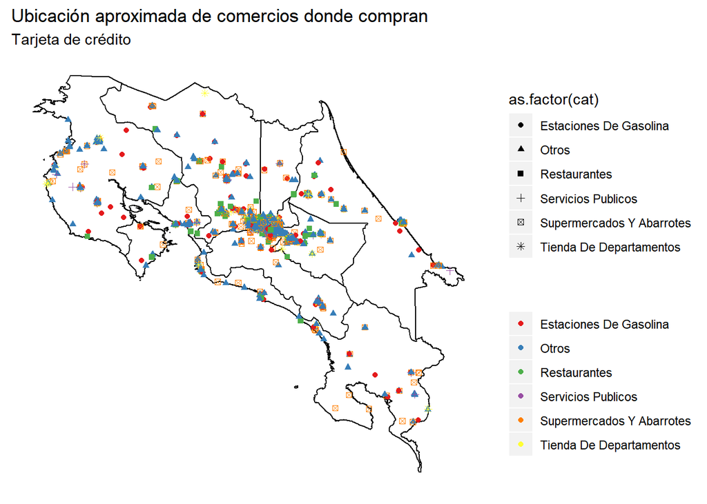

```r
mov <- movimientos %>% select(mcc_cat, comercio) %>%
  group_by(comercio) %>%
  slice(1)

top5 <- c("SUPERMERCADOS Y ABARROTES",
           "ESTACIONES DE GASOLINA",
           "TIENDA DE DEPARTAMENTOS",
           "RESTAURANTES",
           "SERVICIOS PUBLICOS"
)

ubicaciones2 <- ubicaciones %>% left_join(mov, by = "comercio") %>%
  mutate(cat = ifelse(mcc_cat %in% top5, mcc_cat, "OTROS"),
         cat = str_to_title(cat))


ubicaciones2 %>%
  filter(lon < -82, lon > -86, lat < 11.15, lat > 8) %>%
  ggplot(aes(x = lon, y = lat))  +
  geom_polygon(data = map, aes(x = long, y = lat, group = group),
               fill = "white", col = "black", alpha = 0.8) +
  geom_point(aes(col = as.factor(cat), shape = as.factor(cat)), size = 1.5) +
  coord_map() +
  theme(axis.text = element_blank(), axis.ticks = element_blank(),
        panel.background = element_blank(), legend.position = "right",
        axis.title = element_blank(), panel.grid = element_blank()) +
  ggtitle("Ubicación aproximada de comercios donde compran",
          "Tarjeta de crédito") + scale_color_manual(name = "",
        values =  RColorBrewer::brewer.pal(7, "Set1"))
```

# Conclusiones

- Puntos no son precisos.
- Omisión de registros por malas descripciones.
- La información es muy útil comercial y patrón de consumo.
- Colocación de tarjetas y nuevos productos. Recomendación de productos.